# Statistical Analyses with Mixed Models of Human Translation versus Post-editing of Warbreaker’s chapter 1

## 6.3 Ratio of pauses

```r
mydfp$rp_300 <- mydfp$lp_300 / (mydfp$ev_time_ms)
summary(mydfp$rp_300)
```

```
##    Min. 1st Qu.  Median    Mean 3rd Qu.    Max.
## 0.07816 0.53521 0.68534 0.65097 0.79793 0.99414
```

```r
cor(mydfp$rp_300,mydfp$time) # 0.42
```

```
## [1] 0.4184887
```

```r
cor(mydfp$rp_300,mydfp$time.l) # 0.57
```

```
## [1] 0.5680492
```

```r
cor(mydfp$rp_300,mydfp$k_total) # 0.31
```

```
## [1] 0.3038672
```

```r
cor(mydfp$rp_300,mydfp$lp_300) # 0.5
```

```
## [1] 0.5018256
```

Correlation with time is the highest (R=0.57). We will use almost the same predictors, interactions and slopes as in the model used for temporal effort (the model with exactly the same predictors does not converge and therefore we remove the interaction and the slope).

Our reponse variable is a proportion, therefore we use beta regression. There is no implementation of beta regression in lmer, but there is in gam.

```r
m0 = bam(rp_300 ~ len_sl_chr.s + tasktype + trial.s + s(subject,bs='re') + s(item,bs="re"), data=mydfp, family=betar(link="logit"))
summary(m0)
```

```
##
## Family: Beta regression(7.864)
## Link function: logit
##
## Formula:
## rp_300 ~ len_sl_chr.s + tasktype + trial.s + s(subject, bs = "re") +
##     s(item, bs = "re")
##
## Parametric coefficients:
##              Estimate Std. Error t value Pr(>|t|)
## (Intercept)   0.53754    0.09291   5.785 8.51e-09 ***
## len_sl_chr.s  0.26269    0.01837  14.302  < 2e-16 ***
## tasktypemt1   0.10560    0.04005   2.636  0.00845 **
## tasktypemt2   0.09582    0.04022   2.383  0.01729 *
## trial.s      -0.01621    0.01795  -0.903  0.36650
## ---
## Signif. codes:  0 '***' 0.001 '**' 0.01 '*' 0.05 '.' 0.1 ' ' 1
##
## Approximate significance of smooth terms:
##               edf Ref.df      F p-value
## s(subject)  4.839      5 30.057 < 2e-16 ***
## s(item)    64.079    327  0.244 0.00413 **
## ---
## Signif. codes:  0 '***' 0.001 '**' 0.01 '*' 0.05 '.' 0.1 ' ' 1
##
## R-sq.(adj) =   0.22   Deviance explained = 24.7%
## fREML = 2746.3  Scale est. = 1         n = 1877
```

```r
#library(itsadug)
#plot_smooth(m0,view="len_sl_chr.s",rug=F,plot_all="tasktype",transform=plogis)

mydfp$tasktype <- relevel(mydfp$tasktype, "mt1")
m0_mt1 = bam(rp_300 ~ len_sl_chr.s + tasktype + trial.s + s(len_sl_chr.s,by=tasktype) + s(subject,bs='re') + s(item,bs="re"), data=mydfp, family=betar(link="logit"))
summary(m0_mt1)
```

```
##
## Family: Beta regression(7.852)
## Link function: logit
##
## Formula:
## rp_300 ~ len_sl_chr.s + tasktype + trial.s + s(len_sl_chr.s,
##     by = tasktype) + s(subject, bs = "re") + s(item, bs = "re")
##
## Parametric coefficients:
##              Estimate Std. Error t value Pr(>|t|)
## (Intercept)   0.64675    0.09390   6.888 7.79e-12 ***
## len_sl_chr.s  0.29758    0.13103   2.271  0.02326 *
## tasktypeht   -0.11619    0.04005  -2.901  0.00377 **
## tasktypemt2  -0.01476    0.04041  -0.365  0.71490
## trial.s      -0.01609    0.01764  -0.912  0.36185
## ---
## Signif. codes:  0 '***' 0.001 '**' 0.01 '*' 0.05 '.' 0.1 ' ' 1
##
## Approximate significance of smooth terms:
##                                edf  Ref.df      F p-value
## s(len_sl_chr.s):tasktypemt1  2.565   3.186  1.993  0.1088
## s(len_sl_chr.s):tasktypeht   1.702   2.340  2.688  0.0381 *
## s(len_sl_chr.s):tasktypemt2  1.000   1.000  0.147  0.7019
## s(subject)                   4.841   5.000 30.325  <2e-16 ***
## s(item)                     52.691 327.000  0.192  0.0160 *
## ---
## Signif. codes:  0 '***' 0.001 '**' 0.01 '*' 0.05 '.' 0.1 ' ' 1
##
## Rank: 367/368
## R-sq.(adj) =  0.221   Deviance explained = 24.5%
## fREML = 2742.2  Scale est. = 1         n = 1877
```

```r
mydfp$tasktype <- relevel(mydfp$tasktype, "ht")
```

We do two comparisons for the significance of translation condition for level MT2: MT2 vs HT (0.01729) and MT2 vs MT1 (0.71490). Thus we need to correct for multiple comparisons, which we do with Holm-Bonferroni.

```r
p.adjust(c(0.01729, 0.71490), method = "holm")
```

```
## [1] 0.03458 0.71490
```

p (MT2 vs HT) < 0.05 p (MT2 vs MT1) > 0.1

```r
plogis(0.53)
```

```
## [1] 0.6294831
```

```r
plogis(0.53+0.11619)
```

```
## [1] 0.6561514
```

```r
plogis(0.53+0.10143)
```

```
## [1] 0.6528136
```

Intercept = HT (63%). Pause ratio higher with MT1 (65.6) and MT2 (65.3). Both differences are significant. The difference between MT1 and MT2 is not significant.

## 6.4 Distribution of pauses across conditions

Finally we show the distribution of pauses across conditions for each pause-related dependent variable considered: number of pauses, their duration and ratio.

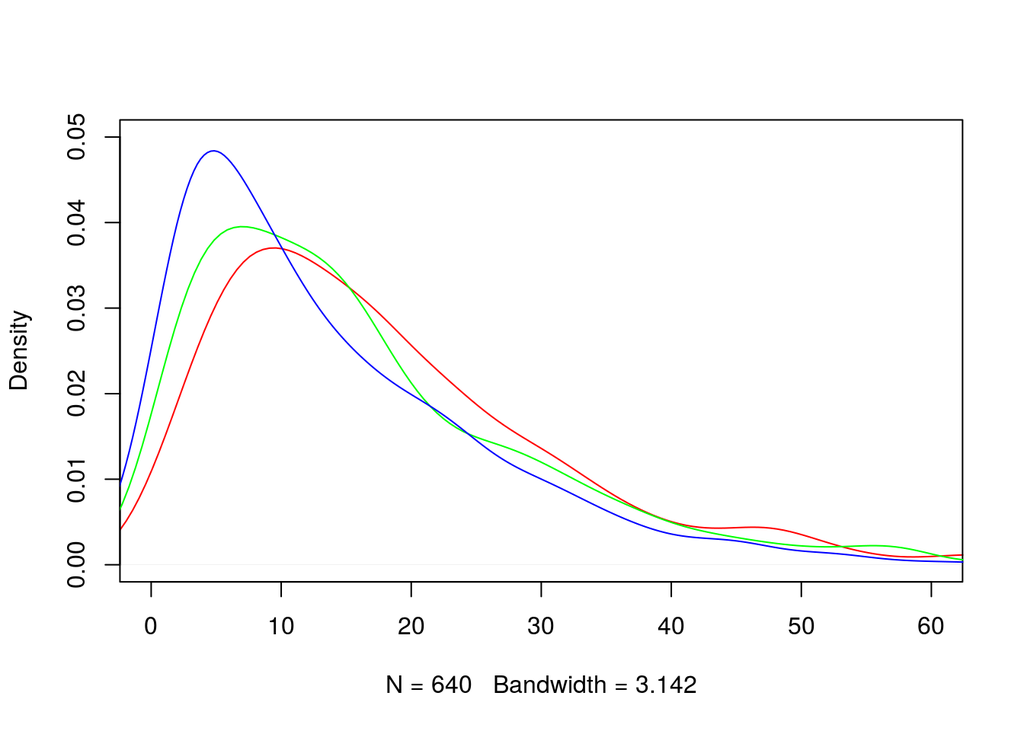

```r
plot(density(mydfp[mydfp$tasktype=="ht",]$np_300), col="red", ylim=c(0,0.05), xlim=c(0,60),  main="") # number of pauses
lines(density(mydfp[mydfp$tasktype=="mt1",]$np_300), col="green")
lines(density(mydfp[mydfp$tasktype=="mt2",]$np_300), col="blue")
```

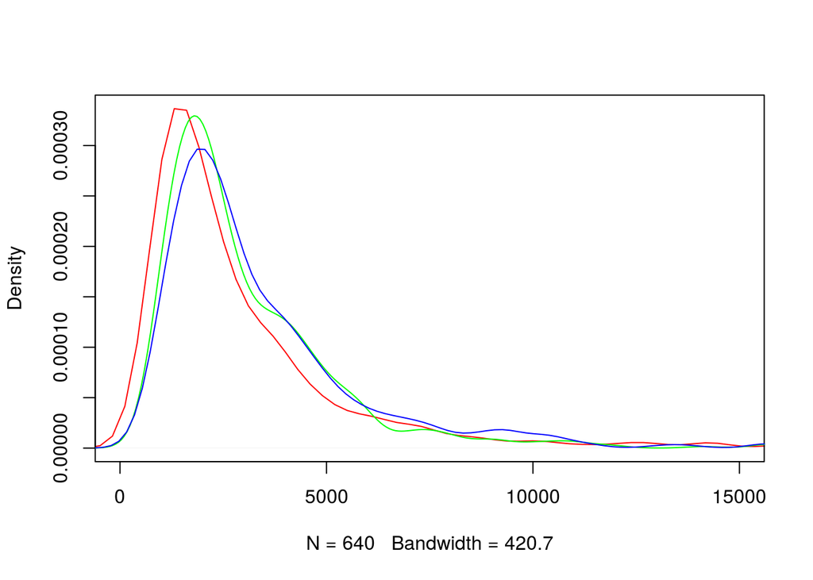

```r
plot(density(mydfp[mydfp$tasktype=="ht",]$mlp_300), col="red", xlim=c(0,15000),  main="") # mean pause duration
lines(density(mydfp[mydfp$tasktype=="mt1",]$mlp_300), col="green")
lines(density(mydfp[mydfp$tasktype=="mt2",]$mlp_300), col="blue")
```

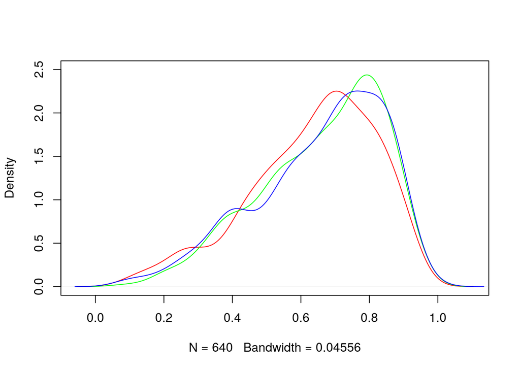

```r
plot(density(mydfp[mydfp$tasktype=="ht",]$rp_300), col="red", ylim=c(0,2.5),  main="") # pause ratio
lines(density(mydfp[mydfp$tasktype=="mt1",]$rp_300), col="green")
lines(density(mydfp[mydfp$tasktype=="mt2",]$rp_300), col="blue")
```